# PSTAT 131 Final Project

Quinn Harrington

## Introduction

### The Basics on LA and Crime

The city of Los Angeles is one of the largest metropolitan areas in the United States and is the most populous city in the state of California with a population of nearly 3.9 million people. Unsurprisingly, with such a dense urban population, there are many, many crimes committed on a daily basis. These crimes range greatly in severity and scale, from offenses as minor as jaywalking and trespassing, to crimes as severe as murder, arson, and rape. The city of Los Angeles and its police department work to identify, address, and prevent crime in all of the 21 neighborhoods within the city limits.

### Goal

As part of these efforts to keep the public informed and increase accountability, the LAPD collects and publishes crime data on a regular basis. The subject of this machine learning project will be the 2020 to 2024 Los Angeles crime data. This dataset contains a variety of information on every crime committed in Los Angeles during this four year period. The goal of this project will be to predict the classiffication of a crime according to a pre-defined scale of severity. While there is a current system of classification for crimes, I hope to train a machine learning model to predict the classification of crimes in a manner that could prove more useful for proactive identification and response to offenses being actively perpetrated.

#### The Current System

Currently, the classification of crimes in this dataset is in accordance with the 2019 FBI Uniform Crime Reporting(UCR) program. The UCR program classifies crimes as either ‘Part I’ or ‘Part II’, based on their severity and rate of occurrence nation-wide.

For Part I offenses, the FBI collects monthly reports from participating law enforcement across the country that contain the number of Part I offenses that are newly known to them, which of these offenses have “been cleared by arrest or exceptional means”(FBI.gov), as well as the age, sex, and race of those who have been arrested for committing any of these offenses. Part I crimes are:

- CRIMINAL HOMICIDE
- FORCIBLE RAPE
- ROBBERY
- AGGRAVATED ASSAULT
- BURGLARY
- LARCENY THEFT
- MOTOR VEHICLE THEFT
- ARSON
- HUMAN TRAFFICKING, COMMERCIAL SEX ACTS
- HUMAN TRAFFICKING, INVOLUNTARY SERVITUDE

Per the UCR webpage on the FBI website, the purpose of the reporting of Part I offenses and information concerning them is:

“The UCR Program collects data about Part I offenses in order to measure the level and scope of crime occurring throughout the nation. The program’s founders chose these offenses because they are serious crimes, they occur with regularity in all areas of the country, and they are likely to be reported to the police.”

For Part 2 offenses, law enforcement agencies participating in the UCR program only provide the FBI with a monthly report containing arrest data on these crimes. Part II crimes are:

- OTHER ASSAULTS (SIMPLE)
- FORGERY AND COUNTERFEITING
- FRAUD
- EMBEZZLEMENT
- STOLEN PROPERTY: BUYING, RECEIVING, POSSESSING
- VANDALISM
- WEAPONS: CARRYING, POSSESSING, ETC.
- PROSTITUTION AND COMMERCIALIZED VICE
- SEX OFFENSES (EXCEPT RAPE, PROSTITUTION, AND COMMERCIALIZED VICE)
- DRUG ABUSE VIOLATIONS
- GAMBLING
- OFFENSES AGAINST THE FAMILY AND CHILDREN
- DRIVING UNDER THE INFLUENCE
- LIQUOR LAWS
- DRUNKENNESS
- DISORDERLY CONDUCT
- VAGRANCY
- ALL OTHER OFFENSES
- SUSPICION
- CURFEW AND LOITERING LAWS (PERSONS UNDER 18)

This is only a list of the offenses categorized by their respective “Part” designation. A detailed explanation of the offenses listed above can be found at the following link:

`https://ucr.fbi.gov/crime-in-the-u.s/2019/crime-in-the-u.s.-2019/topic-pages/offense-definitions`

#### An Alternate Approach

While there is nothing inherently wrong with the FBI’s UCR program, it is mostly focused on the retrospective collection of data on crimes that have been designated as frequent and severe on a national scale. While this data could be very useful for decision-making regarding national law-enforcement policies and directives, it seems less useful on a more local, immediate scale.

I would like to impose a different structure for classification; a four level scale with level 1 indicating minimal severity (response time can be diminished, with more severe crimes addressed first) and level 4 indicating a violent crime with high probability of lethality (response time must be as short as physically possible).

Let the proposed scale be as follows:

1. Low Severity (Lowest Severity) - Offenses include minor, non-violent misdemeanors such as vandalism, petty theft, and trespassing.
2. Moderate Severity - Offenses include more serious misdemeanors and property-related crimes, such as non-violent burglary, grand theft, and identity theft.
3. High Severity - Offenses include non-lethal violent crimes, such as assault, battery, or unarmed robbery.
4. Extreme Severity (Highest Severity) - Offenses include serious, violent crimes with a high plausibility of lethality. All sexual crimes will also be classified as severity 4. Examples of offenses include homicide, rape, armed robbery, and aggravated assault.

Ideally, the prospective model will be able to correctly classify crimes with their appropriate level of severity. A reasonably accurate model could prove useful for responding to new, in-progress crimes that require attention from Los Angeles police officers. The ability to designate and order crimes with regard to their severity could help with the priority of where nearby units are dispatched to first, hopefully saving lives in the process.

## Data Citation

The source of this data is the Los Angeles Police Department. It is publically available on the City of Los Angeles website. The downloadable version of this data can be found at this link:

https://data.lacity.org/Public-Safety/Crime-Data-from-2020-to-Present/2nrs-mtv8/about_data

The official dataset description found on the City of LA website is:

**“This dataset reflects incidents of crime in the City of Los Angeles dating back to 2020. This data is transcribed from original crime reports that are typed on paper and therefore there may be some inaccuracies within the data. Some location fields with missing data are noted as (0°, 0°). Address fields are only provided to the nearest hundred block in order to maintain privacy. This data is as accurate as the data in the database. Please note questions or concerns in the comments.”**

This data is updated on a bi-monthly basis to include the most recent possible information on crimes committed in Los Angeles. To emphasize how many offenses are committed on regular basis, when I first investigated this dataset on August 16th, 2024, there were 966,951 observations. I updated my downloaded dataset with the most recent version on September 11th, 2024, to find that there are now 974,477 observations. In a 26 day period, there were 7,526 additional crimes committed!

## Pre-processing and Tidying

Before we can begin analyzing our data and applying our model creation and fitting processes, we must first ensure the data is appropriately tidied and relevant pre-processing steps are taken. Additionally, we must create the `severity` variable as described in the `Goal` section above, as this will be our outcome variable later on.

### Loading the Data

The dataset has been downloaded from the City of Los Angeles website using the link provided in the “Data Citation” section. Now, we will import the dataset into our R environment to begin examining it.

```r
#Load the LAPD crime dataset from my local directory
LAPDcrimedata <- read.csv("C:/Users/qharr/Dropbox/pstat131/FINAL PROJECT/Crime_Data_from_2020_to_Present_20240911.csv")
```

Now that the dataset is stored as an obect in our R environment, we are able to examine it using various R functions. First, lets check out a very brief preview of what we’re working with to decide how we should procede.

```r
#preview the LAPD dataset
head(LAPDcrimedata)
```

```
##       DR_NO              Date.Rptd               DATE.OCC TIME.OCC AREA
## 1 190326475 03/01/2020 12:00:00 AM 03/01/2020 12:00:00 AM     2130    7
## 2 200106753 02/09/2020 12:00:00 AM 02/08/2020 12:00:00 AM     1800    1
## 3 200320258 11/11/2020 12:00:00 AM 11/04/2020 12:00:00 AM     1700    3
## 4 200907217 05/10/2023 12:00:00 AM 03/10/2020 12:00:00 AM     2037    9
## 5 220614831 08/18/2022 12:00:00 AM 08/17/2020 12:00:00 AM     1200    6
## 6 231808869 04/04/2023 12:00:00 AM 12/01/2020 12:00:00 AM     2300   18
##   AREA.NAME Rpt.Dist.No Part.1.2 Crm.Cd
## 1  Wilshire         784        1    510
## 2   Central         182        1    330
## 3 Southwest         356        1    480
## 4  Van Nuys         964        1    343
## 5 Hollywood         666        2    354
## 6 Southeast        1826        2    354
##                                Crm.Cd.Desc             Mocodes Vict.Age
```

[output cut: 34 more lines]

From the above preview, we can observe the structure of the LA crime data. Each individual observation is the record of one instance of a crime that has been committed. For each crime, there are 28 columns that contain various information describing the offense that occurred. For a full list and description of each of these variables, please refer to the the code-book provided in the zipped final project file.

Now, lets get more of a numerically descriptive idea of the data at hand:

```r
summary(LAPDcrimedata)
```

```
##      DR_NO            Date.Rptd           DATE.OCC            TIME.OCC
##  Min.   :      817   Length:974477      Length:974477      Min.   :   1
##  1st Qu.:210605820   Class :character   Class :character   1st Qu.: 900
##  Median :220808651   Mode  :character   Mode  :character   Median :1420
##  Mean   :219565398                                         Mean   :1339
##  3rd Qu.:230906446                                         3rd Qu.:1900
##  Max.   :249925282                                         Max.   :2359
##
##       AREA        AREA.NAME          Rpt.Dist.No      Part.1.2
##  Min.   : 1.00   Length:974477      Min.   : 101   Min.   :1.000
##  1st Qu.: 5.00   Class :character   1st Qu.: 589   1st Qu.:1.000
##  Median :11.00   Mode  :character   Median :1141   Median :1.000
##  Mean   :10.71                      Mean   :1117   Mean   :1.405
##  3rd Qu.:16.00                      3rd Qu.:1617   3rd Qu.:2.000
##  Max.   :21.00                      Max.   :2199   Max.   :2.000
##
##      Crm.Cd      Crm.Cd.Desc          Mocodes             Vict.Age
##  Min.   :110.0   Length:974477      Length:974477      Min.   : -4.00
##  1st Qu.:331.0   Class :character   Class :character   1st Qu.:  0.00
##  Median :442.0   Mode  :character   Mode  :character   Median : 30.00
##  Mean   :500.7                                         Mean   : 29.17
##  3rd Qu.:626.0                                         3rd Qu.: 44.00
##  Max.   :956.0                                         Max.   :120.00
##
##    Vict.Sex         Vict.Descent         Premis.Cd     Premis.Desc
##  Length:974477      Length:974477      Min.   :101.0   Length:974477
##  Class :character   Class :character   1st Qu.:101.0   Class :character
##  Mode  :character   Mode  :character   Median :203.0   Mode  :character
##                                        Mean   :306.1
##                                        3rd Qu.:501.0
##                                        Max.   :976.0
##                                        NA's   :14
##  Weapon.Used.Cd   Weapon.Desc           Status          Status.Desc
##  Min.   :101.0    Length:974477      Length:974477      Length:974477
##  1st Qu.:311.0    Class :character   Class :character   Class :character
##  Median :400.0    Mode  :character   Mode  :character   Mode  :character
##  Mean   :363.8
##  3rd Qu.:400.0
##  Max.   :516.0
##  NA's   :648695
##     Crm.Cd.1        Crm.Cd.2         Crm.Cd.3         Crm.Cd.4
##  Min.   :110.0   Min.   :210.0    Min.   :310.0    Min.   :821.0
##  1st Qu.:331.0   1st Qu.:998.0    1st Qu.:998.0    1st Qu.:998.0
##  Median :442.0   Median :998.0    Median :998.0    Median :998.0
##  Mean   :500.5   Mean   :958.1    Mean   :984.2    Mean   :991.2
##  3rd Qu.:626.0   3rd Qu.:998.0    3rd Qu.:998.0    3rd Qu.:998.0
##  Max.   :956.0   Max.   :999.0    Max.   :999.0    Max.   :999.0
##  NA's   :11      NA's   :905717   NA's   :972168   NA's   :974413
##    LOCATION         Cross.Street            LAT             LON
##  Length:974477      Length:974477      Min.   : 0.00   Min.   :-118.7
##  Class :character   Class :character   1st Qu.:34.01   1st Qu.:-118.4
##  Mode  :character   Mode  :character   Median :34.06   Median :-118.3
##                                        Mean   :34.00   Mean   :-118.1
##                                        3rd Qu.:34.16   3rd Qu.:-118.3
##                                        Max.   :34.33   Max.   :   0.0
##
```

From the above summary statistics regarding each variable, we can see that there is quite a bit going on- almost too much. We need to mess with this data to make it a bit more manageable. The most glaringly obvious issue here is the sheer size of the dataset; we have records on 974,477 individual crimes!

During the introduction for this project, we mentioned the creation of a `severity` variable to provide more useful labeling of crimes committed in Los Angeles. This variable has not yet been created, so we must accomplish this task before proceeding with the modeling process.

Additionally, we should note that there are multiple variables that have missing data for observations in our dataset. These variables are: `Premis.Cd` (14 missing), `Weapon.Used.Cd`(648,695 missing), `Crm.Cd.1`(11 missing), `Crm.Cd.2`(905,717 missing), `Crm.Cd.3`(972,168 missing), and `Crm.Cd.4`(974,413 missing). Missing data must be considered and handled appropriately due to how it might affect our prospective models. Once the `severity` variable is created, it will also be necessary to examine whether or not the newly created `severity` variable has any missing entries. If there are missing entries, it will be necessary to re-visit the process used to create this variable and ensure I have not made any mistakes.dww

### Reducing Size

Firstly, let us tackle the issue of this dataset’s magnitude. We have 974,477 observations, with 28 variables for each observation. Let’s reduce the size of our dataset.

My initial approach to reducing the size of the dataset was to select the three neighborhoods with the highest total crime count over the four year period for which the `LAPDcrimedata` dataset accounts for. This seems like an okay idea at first, but later it seemed damaging, as I could not use geographic predictors very well, as there was not a ton of variation in geographic area. Additionally, taking the top three neighborhoods for crime count still leaves us with somewhere in the neighborhood of 185,000 observations.

Instead of choosing the top three neighborhoods, let’s take a random sample of 1000 observations from each of the 21 neighborhoods in the LA City limits. By doing this, we get a wider range of observations throughout the city. Not only will this result in a smaller dataset than taking just the three neighborhoods with the most crime, it should make our results later on more generally applicable.

```r
LA_crime_subset <- LAPDcrimedata %>%
  group_by(AREA.NAME) %>%
  slice_sample(n=1000) %>%
  ungroup()

counts_by_area <- LA_crime_subset %>%
  group_by(AREA.NAME) %>%
  summarize(count = n()) %>%
  arrange(desc(count))
print(counts_by_area)
```

```
## # A tibble: 21 × 2
##    AREA.NAME   count
##    <chr>       <int>
##  1 77th Street  1000
##  2 Central      1000
##  3 Devonshire   1000
##  4 Foothill     1000
##  5 Harbor       1000
##  6 Hollenbeck   1000
##  7 Hollywood    1000
##  8 Mission      1000
##  9 N Hollywood  1000
## 10 Newton       1000
## # ℹ 11 more rows
```

Now, the `LA_crime_subset` dataset stores 1000 observations from each neighborhood, for a total observation count of 21,000. This reduction in size will hopefully capture a happy medium between the ability to generalize the models we will fit later and a reduction in required processing power to fit these models.

### Reducing dimensionality

The second step in making this dataset more manageable lies in reducing its dimensionality. At the current moment, we have 28 variables. While some of these variables could possibly prove to be productive to our prospective models during the EDA process that will come slightly later, others are obviously not very useful. Let’s take a look at the codebook I have created to explain the variables in our dataset:

**Click to view the LAPD crime data codebook**

```r
# Read the codebook from the .txt file
codebook <- readLines("C:/Users/qharr/Dropbox/pstat131/FINAL PROJECT/crimedata_codebook.txt")

cat(codebook, sep = "\n")
```

```
## ORDER / VARIABLE NAME / VARIABLE TYPE(format:TYPE(distinction)) / DESCRIPTION
##
## 1. DR_NO - CHARACTER(string) - Division of Records Number: Official file number made up of a 2 digit year, area ID, and 5 digits.
##
## 2. Date Rptd - DATE - MM/DD/YYYY date entry of when the crime was reported.
##
## 3. DATE OCC - DATE - MM/DD/YYYY date entry of when the crime occurred.
##
## 4. TIME OCC - NUMERIC(integer) - The time at which the crime occurred, notated in 24 hour military time.
##
## 5. AREA - NUMERIC(categorical) - The LAPD has 21 Community Police Stations referred to as Geographic Areas within the department. These Geographic Areas are sequentially numbered from 1-21.
##
## 6. AREA NAME - CHARACTER(string) - The 21 Geographic Areas or Patrol Divisions are also given a name designation that references a landmark or the surrounding community that it is responsible for. For example 77th Street Division is located at the intersection of South Broadway and 77th Street, s…
##
## 7. Rpt Dist No - CHARACTER(string) - A four-digit code that represents a sub-area within a Geographic Area. All crime records reference the "RD" that it occurred in for statistical comparisons. Find LAPD Reporting Districts on the LA City GeoHub at http://geohub.lacity.org/datasets/c4f83909b81d47…
##
## 8. Part 1-2 - NUMERIC(categorical) - The FBI has defined certain crimes to be either part 1 or part 2.
##
## 9. Crm CD - NUMERIC(Categorical) - Indicates the crime committed, using its assigned numerical code. (Same as Crime Code 1).
##
## 10. Crm CD Desc - CHARACTER(string) - Defines the Crime Code provided.
##
## 11. Mocodes - NUMERIC(categorical) - Modus Operandi: Activities associated with the suspect in commission of the crime. See attached PDF for list of MO Codes in numerical order. https://data.lacity.org/api/views/y8tr-7khq/files/3a967fbd-f210-4857-bc52-60230efe256c?download=true&filename=MO%20CODE…
##
## 12. Vict Age - NUMERIC(integer) - Two character numeric.
##
## 13. Vict Sex - CHARACTER(categorical) - F - Female M - Male X - Unknown.
##
## 14. Vict Descent - CHARACTER(categorical) - Contains a code to reference the victim's ethnic descent. Descent Code: A - Other Asian B - Black C - Chinese D - Cambodian F - Filipino G - Guamanian H - Hispanic/Latin/Mexican I - American Indian/Alaskan Native J - Japanese K - Korean L - Laotian O - …
##
## 15. Premis Cd - NUMERIC(categorical) - The type of structure, vehicle, or location where the crime took place.
##
## 16. Premis Desc - CHARACTER(string) - Defines the Premise Code provided.
##
## 17. Weapon Used Cd - NUMERIC(categorical) - The type of weapon used in the crime.
##
## 18. Weapon Desc - CHARACTER(string) - Defines the Weapon Used Code provided.
##
## 19. Status - TEXT - CHARACTER(categorical). (IC is the default).
##
```

[output cut: 21 more lines]

```
## 1. Weapon.Used - INTEGER(categorical) - contains a 0 if a weapon was not used in the perpetration of the crime, 1 if a weapon was used
##
## 2. Severity - INTEGER(categorical) - contains a ranking 1,2,3, or 4 which grades the severity of a crime. 1 is the least severe, 4 is the most severe. Severity was decided based on Crm.Cd values and their corresponding Crm.Cd.Desc crime descriptions.
##
## 3. Year.OCC - INTEGER(categorical) - contains the year a crime occurred in a YYYY format. Possible values are 2020, 2021, 2022, 2023, or 2024.
##
## 4. Month.OCC - INTEGER(categorical) - contains the month a crime occurred based on the month's place in the sequential 12 month ordering. Possible values are 1,2,3,4,5,6,7,8,9,10,11,12.
##
## 5. Weekday.OCC - CHARACTER(categorical) - contains the day of the week on which the crime occurred, possible values are Monday, Tuesday, Wednesday, Thursday, Friday, Saturday, or Sunday.
##
## 6. Season.OCC - CHARACTER(categorical) - contains the season during which the crime occurred, possible values are Winter, Spring, Summer, or Fall.
##
## 7. Time.Period - CHARACTER(categorical) - contains the time period of the day during which a crime was committed. Crimes committed from 12:00AM - 4AM are Early Morning, 4:01AM - 9PM are Day time, and 9:01PM -11:59pm are Night Time.
##
## 8. WEEKEND - BINARY(logical) - contains either TRUE or FALSE, WEEKEND is TRUE if the crime was committed on Saturday or Sunday and FALSE otherwise.
```

From the codebook, we can notice that there are some variables that can likely be removed off-the-bat, as they either contain information that is not useful for our model, or duplicate information that makes it redundant to use both variables with this information.

Additionally, some variables are there primarily for human-interpretability. We can use these variables to understand our observations better, but they will not provide any meaningful input to the model, as they are character strings. We can keep these variables in the larger `LAPDcrimedata` dataset, but they are not necessary in `LA_crime_subset` which we will be using for our modeling process.

Lets identify those variables:

Let’s remove these variables:

```r
LA_crime_subset <- LA_crime_subset %>%
  select(-DR_NO,-Status,-Status.Desc,-Crm.Cd.1,-Crm.Cd.Desc,-Premis.Desc,-Date.Rptd,-Mocodes)
```

While I suspect that some of the other variables will be able to be removed later, there is a chance some introduce meaningful additions to our model. as a result, I will keep the remaining variables, at least through our EDA section.

### Handling Missing Data

When we first loaded and summarized our dataset, we saw that some variables had missing entries for some observations. Recall that these variables and the number of missing entries per were:

1. `Premis.Cd` (14 missing)
- We may not have to handle missing `Premis.Cd` values. Let’s see if the smaller `LA_crime_subset` dataset has any missing values for this variable:

```r
sum(is.na(LA_crime_subset$Premis.Cd))
```

```
## [1] 0
```

There are no missing values, which means we don’t need to take any further action.

2. `Weapon.Used.Cd`(648,695 missing)
- To handle missing values for `Weapon.Used.Cd` I believe it is most appropriate to feature-engineer a new variable, `Weapon.Used`. This is because, regardless of what weapon is used, the fact that any weapon is employed almost guarantees that a crime will be of a high `severity` value according to the scale we have designated. Let’s create this new variable and remove the old variable. Additionally, since we are not interested in what kind of weapon was used, we can also remove the `WeaponDesc` variable:

```r
LA_crime_subset <- LA_crime_subset %>%
  mutate(Weapon.Used = ifelse(is.na(Weapon.Used.Cd),0,1)) %>%
  select(-Weapon.Used.Cd,-Weapon.Desc)
```

3. `Crm.Cd.1`(11 missing)
- We have already handled missing values for `Crm.Cd.1` by removing it from our smaller `LA_crime_subset` dataset. This should not introduce bias and/or inaccuracy, as this was a redundant variable anyways.
4. `Crm.Cd.2`(905,717 missing)
5. `Crm.Cd.3`(972,168 missing)
6. `Crm.Cd.4`(974,413 missing)
- For the seccond, third, and fourth crime code variables, it is logical to remove them. We are only concerned with the primary crime when predicting `severity` which is already stored in `Crm.Cd`. This reasoning, in addition to the fact that these variables have so many missing values suggests that their presence will not add anything meaningful to our model. Let’s remove them from our dataset:

```r
LA_crime_subset <- LA_crime_subset %>%
  select(-Crm.Cd.2,-Crm.Cd.3,-Crm.Cd.4)
```

## Feature Engineering

### Introducing the New Variable

As discussed in the introduction, we will be creating a `severity` variable to provide some insight for police officers and dispatchers to refer to when considering where their attention is most warranted with regards to crimes currently in progress.

To recap, the UCR program created by the FBI assigns offenses a designation of part 1 or part 2, with regards to the severity and frequency of occurrence. More information is collected on part 1 crimes than part 2 crimes and this data is used to guide nationwide law enforcement policy and directives. A `Part.1.2` variable is currently included in our dataset to encode each observation’s designation with regards to the FBI UCR program.

Recall that the scale of the newly proposed `severity` variable is as follows:

1. Low Severity (Lowest Severity) - Offenses include minor, non-violent misdemeanors such as vandalism, petty theft, and trespassing.
2. Moderate Severity - Offenses include more serious misdemeanors and property-related crimes, such as non-violent burglary, grand theft, and identity theft.
3. High Severity - Offenses include non-lethal violent crimes, such as assault, battery, or unarmed robbery.
4. Extreme Severity (Highest Severity) - Offenses include serious, violent crimes with a high plausibility of lethality. All sexual crimes will also be classified as severity 4. Examples of offenses include homicide, rape, armed robbery, and aggravated assault.

Now… for the heavy lifting!

Appropriately identifying which crimes are of which `severity` and assigning the corresponding `Crm.Code` to its respective `severity` value could prove to be a rather arduous process. Let’s make a basic plan of attack, stepwise:

1. Identify all unique crime codes stored in `Crm.Code` in `LAPDcrimedata`
2. Create a look-up table that encodes key/value pairs between these crime codes and their corresponding `severity` value
3. Apply this look-up table to the smaller `LA_crime_subset` dataset to create a new variable, `severity`, and assign all observations a value for this variable based on their `Crm.Code` value.

In case you have not read the attached codebook, `Crm.Cd.1` is designated to contain the most severe offense being committed in each instance of crime. For example, if a homicide was in progress and the suspect also happened to be nude in public, `Crm.Cd.1` would contain the code for homicide, not public nudity or indecent exposure. One of the subsequent crime code variables, `Crm.Cd.2`,`Crm.Cd.3`, or `Crm.Cd.4` would contain the indecent exposure code. Furthermore, `Crm.Cd.1` and `Crm.Cd` contain the same value. Although they store the same code, when we ran our summary of the dataset earlier, `Crm.Cd.1` had a couple of missing values, while `Crm.Cd` had zero missing values. As a result, for the creation of the `severity` variable’s look-up tables, it seems most appropriate to examine the `Crm.Cd` variable.

We will now find all unique values of the `Crm.Cd` variable:

```r
crm_codes<- LAPDcrimedata %>%
  select(Crm.Cd,Crm.Cd.Desc) %>%
  distinct()
kable(crm_codes) %>%
  scroll_box(height="300px")
```

| Crm.Cd | Crm.Cd.Desc |
| --- | --- |
| 510 | VEHICLE - STOLEN |
| 330 | BURGLARY FROM VEHICLE |
| 480 | BIKE - STOLEN |
| 343 | SHOPLIFTING-GRAND THEFT ($950.01 & OVER) |
| 354 | THEFT OF IDENTITY |
| 624 | BATTERY - SIMPLE ASSAULT |
| 821 | SODOMY/SEXUAL CONTACT B/W PENIS OF ONE PERS TO ANUS OTH |
| 812 | CRM AGNST CHLD (13 OR UNDER) (14-15 & SUSP 10 YRS OLDER) |
| 230 | ASSAULT WITH DEADLY WEAPON, AGGRAVATED ASSAULT |
| 956 | LETTERS, LEWD - TELEPHONE CALLS, LEWD |
| 341 | THEFT-GRAND ($950.01 & OVER)EXCPT,GUNS,FOWL,LIVESTK,PROD |
| 930 | CRIMINAL THREATS - NO WEAPON DISPLAYED |
| 668 | EMBEZZLEMENT, GRAND THEFT ($950.01 & OVER) |
| 420 | THEFT FROM MOTOR VEHICLE - PETTY ($950 & UNDER) |
| 813 | CHILD ANNOYING (17YRS & UNDER) |
| 440 | THEFT PLAIN - PETTY ($950 & UNDER) |
| 626 | INTIMATE PARTNER - SIMPLE ASSAULT |
| 762 | LEWD CONDUCT |
| 441 | THEFT PLAIN - ATTEMPT |
| 310 | BURGLARY |
| 331 | THEFT FROM MOTOR VEHICLE - GRAND ($950.01 AND OVER) |
| 210 | ROBBERY |
| 662 | BUNCO, GRAND THEFT |
| 860 | BATTERY WITH SEXUAL CONTACT |
| 236 | INTIMATE PARTNER - AGGRAVATED ASSAULT |
| 820 | ORAL COPULATION |
| 661 | UNAUTHORIZED COMPUTER ACCESS |
| 810 | SEX,UNLAWFUL(INC MUTUAL CONSENT, PENETRATION W/ FRGN OBJ |
| 901 | VIOLATION OF RESTRAINING ORDER |
| 442 | SHOPLIFTING - PETTY THEFT ($950 & UNDER) |

[output cut: 109 more lines]

```r
#I exported the crm_codes object as csv to make it easier for me to assign severity values using excel to view the whole table.
#write.csv(crm_codes, "C:/Users/qharr/Downloads/codes.csv", row.names = FALSE)
```

Now that we possess all of the relevant crime codes and their descriptions, we can proceed to creating the look-up table to match crimes to their appropriate `severity` values. Before we can create the structure of the look-up table itself, we must assign `severity` levels to each value of `Crm.Cd`.

Using each crime’s description, there is a fairly logical `severity` value to match it with. Technically, the fact that I am the one designating `severity` values for each `Crm.Cd` creates the possibility that I will introduce inaccuracy/bias into the data. I am fully aware of this fact, but I believe that the `severity` values I have designated fully align with morals held by most of society in the United States. Earlier, I stated that `severity` values of four are for the worst offenses possible. I have decided that in addition to crimes that have the immediate possibility of a loss of life, `severity` will also include sexual crimes due to their inherently violent and damaging nature. Additionally, since the goal of the creation of the `severity` variable is to judge the scope of the worst offense in an instance of crime, it is unnecessary to consider the secondary crime code variables in the designation of `severity`values.

The following table expresses each `Crm.Cd` along with its `Crm.Cd.Desc`, with the corresponding `severity` value:

```r
#first, I bring in the csv file where I saved the crm.cd values with their corresponding severity values
crmcd_severity <-read_csv("C:/Users/qharr/Downloads/codes.csv")

kable(crmcd_severity, caption = "Crm.Cd Values and Their Corresponding Severities") %>%
  scroll_box(height="300px")
```

Crm.Cd Values and Their Corresponding Severities

| Crm.Cd | Crm.Cd.Desc | Severity |
| --- | --- | --- |
| 510 | VEHICLE - STOLEN | 2 |
| 330 | BURGLARY FROM VEHICLE | 2 |
| 480 | BIKE - STOLEN | 2 |
| 343 | SHOPLIFTING-GRAND THEFT ($950.01 & OVER) | 2 |
| 354 | THEFT OF IDENTITY | 2 |
| 624 | BATTERY - SIMPLE ASSAULT | 3 |
| 821 | SODOMY/SEXUAL CONTACT B/W PENIS OF ONE PERS TO ANUS OTH | 4 |
| 812 | CRM AGNST CHLD (13 OR UNDER) (14-15 & SUSP 10 YRS OLDER) | 4 |
| 230 | ASSAULT WITH DEADLY WEAPON, AGGRAVATED ASSAULT | 4 |
| 956 | LETTERS, LEWD - TELEPHONE CALLS, LEWD | 1 |
| 341 | THEFT-GRAND ($950.01 & OVER)EXCPT,GUNS,FOWL,LIVESTK,PROD | 2 |
| 930 | CRIMINAL THREATS - NO WEAPON DISPLAYED | 3 |
| 668 | EMBEZZLEMENT, GRAND THEFT ($950.01 & OVER) | 2 |
| 420 | THEFT FROM MOTOR VEHICLE - PETTY ($950 & UNDER) | 1 |
| 813 | CHILD ANNOYING (17YRS & UNDER) | 3 |
| 440 | THEFT PLAIN - PETTY ($950 & UNDER) | 1 |
| 626 | INTIMATE PARTNER - SIMPLE ASSAULT | 3 |
| 762 | LEWD CONDUCT | 3 |
| 441 | THEFT PLAIN - ATTEMPT | 2 |
| 310 | BURGLARY | 2 |
| 331 | THEFT FROM MOTOR VEHICLE - GRAND ($950.01 AND OVER) | 2 |
| 210 | ROBBERY | 3 |
| 662 | BUNCO, GRAND THEFT | 2 |
| 860 | BATTERY WITH SEXUAL CONTACT | 4 |
| 236 | INTIMATE PARTNER - AGGRAVATED ASSAULT | 4 |
| 820 | ORAL COPULATION | 4 |
| 661 | UNAUTHORIZED COMPUTER ACCESS | 2 |
| 810 | SEX,UNLAWFUL(INC MUTUAL CONSENT, PENETRATION W/ FRGN OBJ | 4 |
| 901 | VIOLATION OF RESTRAINING ORDER | 2 |
| 442 | SHOPLIFTING - PETTY THEFT ($950 & UNDER) | 1 |

[output cut: 109 more lines]

Now that we have designated `severity` values for all possible `Crm.Cd` values, we can proceed with creating the lookup table that will later be applied to our `LA_crime_subset` dataset. Observe the following:

```r
crm_cd_severity <- data.frame(
  Crm.Cd = c(510, 330, 480, 343, 354, 624, 821, 812, 230, 956, 341, 930, 668, 420, 813, 440, 626, 762, 441, 310, 331, 210, 662, 860, 236, 820, 661, 810, 901, 442, 740, 946, 761, 649, 845, 121, 745, 627, 653, 928, 815, 940, 625, 352, 648, 886, 666, 921, 805, 932, 900, 903, 439, 954, 434, 235, 220, 654, 922, 760, 670, 850, 237, 763, 345, 888, 320, 122, 753, 822, 520, 806, 906, 437, 410, 350, 623, 522, 450, 890, 755, 231, 664, 251, 951, 920, 250, 470, 902, 647, 651, 910, 110, 351, 421, 444, 814, 756, 433, 931, 435, 438, 443, 660, 950, 622, 943, 487, 949, 933, 865, 474, 652, 113, 446, 475, 471, 451, 436, 485, 944, 349, 942, 347, 353, 870, 473, 880, 452, 924, 840, 948, 884, 904, 830, 432, 882, 445, 926),
  Severity = c(2, 2, 2, 2, 2, 3, 4, 4, 4, 1, 2, 3, 2, 1, 3, 1, 3, 3, 2, 2, 2, 3, 2, 4, 4, 4, 2, 4, 2, 1, 2, 1, 3, 2, 3, 4, 1, 4, 2, 2, 4, 3, 3, 2, 4, 1, 2, 4, 3, 2, 2, 1, 1, 1, 3, 4, 3, 2, 4, 4, 2, 3, 3, 3, 2, 1, 2, 4, 4, 4, 2, 3, 2, 2, 2, 2, 3, 2, 2, 1, 3, 4, 2, 4, 2, 4, 4, 2, 2, 3, 2, 4, 4, 2, 2, 2, 4, 3, 2, 1, 4, 2, 2, 2, 2, 3, 3, 2, 1, 2, 4, 1, 1, 4, 2, 2, 1, 2, 4, 2, 3, 2, 3, 2, 2, 3, 2, 1, 2, 2, 4, 1, 1, 2, 4, 1, 3, 2, 3)
)
```

Now that we have the `crm_cd_severity` dataframe, we can merge this object with the `LA_crime_subset` dataset using a left-join on the `Crm.Cd` variable to create a new column for all observations that will store the `severity` value for each offense’s `Crm.Cd`.

```r
#merge dataset with look-up table dataframe using a left-join
LA_crime_subset <- LA_crime_subset %>%
  left_join(crm_cd_severity, by = "Crm.Cd")
```

Let’s confirm the presence of `severity` in `LA_crime_subset`

```r
#confirm the merge was succesful by previewing using head()
head(LA_crime_subset)
```

```
## # A tibble: 6 × 17
##   DATE.OCC         TIME.OCC  AREA AREA.NAME Rpt.Dist.No Part.1.2 Crm.Cd Vict.Age
##   <chr>               <int> <int> <chr>           <int>    <int>  <dbl>    <int>
## 1 12/30/2023 12:0…     1030    12 77th Str…        1265        2    753        0
## 2 08/12/2021 12:0…     2000    12 77th Str…        1235        1    310        0
## 3 08/07/2021 12:0…     1800    12 77th Str…        1258        2    903       29
## 4 05/21/2020 12:0…     1130    12 77th Str…        1211        1    236       54
## 5 03/20/2021 12:0…     2100    12 77th Str…        1251        2    812        5
## 6 07/03/2023 12:0…     2000    12 77th Str…        1273        1    510        0
## # ℹ 9 more variables: Vict.Sex <chr>, Vict.Descent <chr>, Premis.Cd <int>,
## #   LOCATION <chr>, Cross.Street <chr>, LAT <dbl>, LON <dbl>,
## #   Weapon.Used <dbl>, Severity <dbl>
```

`Severity` is now a variable in our dataset, so our outcome variable now exists!

### Adressing Date Variables

We already removed the `DATE.RPTD` variable due to its non-usefulness. There is one date variable left, `DATE.OCC` which will likely be useful- but first it requires some tinkering!

1. Year that the crime occurred
- Since we have four years of data, knowing the year could help predict `severity`
2. Month that the crime occurred
- Certain months of the year may have different frequencies of occurrence of crime or more severe crimes that occur during those months
3. Day of the week that the crime occurred
- Different days of the week(especially weekends) could have different frequencies of occurrence of crime or more severe crimes that occur on those days.
4. Season during which the crime occurred
- We all know that different seasons come with different emotions and events (don’t bring up politics at Thanksgiving!), therefore incorporating a variable that encodes the season during which a crime occurred could help predict severity.

Let’s create some new variables to store this possibly useful information for each observation. Once these variables are created, we can remove the original `DATE.OCC` variable.

```r
LA_crime_subset <- LA_crime_subset %>%
  mutate(Year.OCC = year(as.Date(DATE.OCC,format="%m/%d/%Y")),
    Month.OCC = month(as.Date(DATE.OCC,format="%m/%d/%Y")),
    Weekday.OCC = wday(as.Date(DATE.OCC,format="%m/%d/%Y"), label = TRUE),
    Season.OCC = case_when(
      Month.OCC %in% c(12, 1, 2) ~ "Winter",
      Month.OCC %in% c(3, 4, 5) ~ "Spring",
      Month.OCC %in% c(6, 7, 8) ~ "Summer",
      Month.OCC %in% c(9, 10, 11) ~ "Fall"))

LA_crime_subset <- LA_crime_subset %>%
  select(-DATE.OCC)
```

Now, we have four additional variables `Year.OCC`, `Month.Occ`, `Weekday.OCC`, and `Season.OCC`. We also removed the `DATE.OCC` variable, as all of its relevant information is encoded in the four new variables that are now a part of the `LA_crime_subset` dataset. We will discover whether these new variables were actually worth our time to create once we reach the EDA section of this project.

### Addressing Variable Types

Let’s take a final look at our `LA_crime_subset` dataset and ensure everything is in order before we proceed to our EDA section.

```r
summary(LA_crime_subset)
```

```
##     TIME.OCC         AREA     AREA.NAME          Rpt.Dist.No      Part.1.2
##  Min.   :   1   Min.   : 1   Length:21000       Min.   : 101   Min.   :1.000
##  1st Qu.: 915   1st Qu.: 6   Class :character   1st Qu.: 636   1st Qu.:1.000
##  Median :1430   Median :11   Mode  :character   Median :1144   Median :1.000
##  Mean   :1348   Mean   :11                      Mean   :1146   Mean   :1.407
##  3rd Qu.:1900   3rd Qu.:16                      3rd Qu.:1676   3rd Qu.:2.000
##  Max.   :2359   Max.   :21                      Max.   :2197   Max.   :2.000
##
##      Crm.Cd         Vict.Age       Vict.Sex         Vict.Descent
##  Min.   :110.0   Min.   :-2.00   Length:21000       Length:21000
##  1st Qu.:331.0   1st Qu.: 0.00   Class :character   Class :character
##  Median :442.0   Median :30.00   Mode  :character   Mode  :character
##  Mean   :501.7   Mean   :29.38
##  3rd Qu.:626.0   3rd Qu.:45.00
##  Max.   :956.0   Max.   :99.00
##
##    Premis.Cd       LOCATION         Cross.Street            LAT
##  Min.   :101.0   Length:21000       Length:21000       Min.   : 0.00
##  1st Qu.:101.0   Class :character   Class :character   1st Qu.:34.02
##  Median :203.0   Mode  :character   Mode  :character   Median :34.07
##  Mean   :305.5                                         Mean   :33.99
##  3rd Qu.:501.0                                         3rd Qu.:34.18
##  Max.   :971.0                                         Max.   :34.33
##
##       LON          Weapon.Used       Severity        Year.OCC
##  Min.   :-118.7   Min.   :0.000   Min.   :1.000   Min.   :2020
##  1st Qu.:-118.4   1st Qu.:0.000   1st Qu.:2.000   1st Qu.:2021
##  Median :-118.3   Median :0.000   Median :2.000   Median :2022
##  Mean   :-118.1   Mean   :0.334   Mean   :2.223   Mean   :2022
##  3rd Qu.:-118.3   3rd Qu.:1.000   3rd Qu.:3.000   3rd Qu.:2023
##  Max.   :   0.0   Max.   :1.000   Max.   :4.000   Max.   :2024
##
##    Month.OCC      Weekday.OCC  Season.OCC
##  Min.   : 1.000   Sun:2948    Length:21000
##  1st Qu.: 3.000   Mon:2986    Class :character
##  Median : 6.000   Tue:2877    Mode  :character
##  Mean   : 6.278   Wed:2978
##  3rd Qu.: 9.000   Thu:2936
##  Max.   :12.000   Fri:3197
##                   Sat:3078
```

The last thing about our remaining 20 variables that sticks out is their various types. Many of these variables are categorical and are more properly stored as factor variables to represent their categorical nature. Let’s address this:

```r
LA_crime_subset$AREA <- as.factor(LA_crime_subset$AREA)

LA_crime_subset$Rpt.Dist.No <- as.factor(LA_crime_subset$Rpt.Dist.No)

LA_crime_subset$Part.1.2 <- as.factor(LA_crime_subset$Part.1.2)

LA_crime_subset$Crm.Cd <- as.factor(LA_crime_subset$Crm.Cd)

LA_crime_subset$Vict.Sex <- as.factor(LA_crime_subset$Vict.Sex)

LA_crime_subset$Vict.Descent <- as.factor(LA_crime_subset$Vict.Descent)

LA_crime_subset$Premis.Cd <- as.factor(LA_crime_subset$Premis.Cd)

LA_crime_subset$Severity <- factor(LA_crime_subset$Severity,levels = c(1,2,3,4),ordered=TRUE)

LA_crime_subset$Weapon.Used <- as.factor(LA_crime_subset$Weapon.Used)

LA_crime_subset$Weekday.OCC <- as.factor(LA_crime_subset$Weekday.OCC)

LA_crime_subset$Season.OCC <- as.factor(LA_crime_subset$Season.OCC)

LA_crime_subset$Year.OCC <- as.factor(LA_crime_subset$Year.OCC)

LA_crime_subset$Month.OCC <- as.factor(LA_crime_subset$Month.OCC)

LA_crime_subset$AREA.NAME<- as.factor(LA_crime_subset$AREA.NAME)

LA_crime_subset$LOCATION <- as.factor(LA_crime_subset$LOCATION)

LA_crime_subset$Cross.Street <- as.factor(LA_crime_subset$Cross.Street)
```

Now that we have applied these conversions to our categorical variables, let’s ensure that the conversions occurred correctly:

```r
summary(LA_crime_subset)
```

```
##     TIME.OCC         AREA             AREA.NAME      Rpt.Dist.No    Part.1.2
##  Min.   :   1   1      : 1000   77th Street: 1000   645    :  104   1:12447
##  1st Qu.: 915   2      : 1000   Central    : 1000   2156   :   92   2: 8553
##  Median :1430   3      : 1000   Devonshire : 1000   162    :   87
##  Mean   :1348   4      : 1000   Foothill   : 1000   1764   :   81
##  3rd Qu.:1900   5      : 1000   Harbor     : 1000   636    :   80
##  Max.   :2359   6      : 1000   Hollenbeck : 1000   1313   :   80
##                 (Other):15000   (Other)    :15000   (Other):20476
##      Crm.Cd         Vict.Age     Vict.Sex  Vict.Descent    Premis.Cd
##  510    : 2344   Min.   :-2.00    :2935   H      :6449   101    :5480
##  624    : 1616   1st Qu.: 0.00   -:   1   W      :4312   501    :3555
##  354    : 1329   Median :30.00   F:7550          :2936   502    :2422
##  330    : 1297   Mean   :29.38   H:   3   B      :2619   108    :1440
##  740    : 1242   3rd Qu.:45.00   M:8533   X      :2188   203    : 967
##  310    : 1222   Max.   :99.00   X:1978   O      :1647   102    : 834
##  (Other):11950                            (Other): 849   (Other):6302
##                                      LOCATION
##  9300    TAMPA                        AV :   39
##  800 N  ALAMEDA                      ST  :   36
##  100    THE GROVE                    DR  :   33
##  BROADWAY                                :   33
##  6TH                          ST         :   31
##  10200    SANTA MONICA                 BL:   30
##  (Other)                                 :20798
##                           Cross.Street        LAT             LON
##                                 :17885   Min.   : 0.00   Min.   :-118.7
##  BROADWAY                       :   47   1st Qu.:34.02   1st Qu.:-118.4
##  FIGUEROA                     ST:   44   Median :34.07   Median :-118.3
##  WESTERN                      AV:   38   Mean   :33.99   Mean   :-118.1
##  VERMONT                      AV:   35   3rd Qu.:34.18   3rd Qu.:-118.3
##  SAN PEDRO                      :   30   Max.   :34.33   Max.   :   0.0
##  (Other)                        : 2921
##  Weapon.Used Severity  Year.OCC      Month.OCC    Weekday.OCC  Season.OCC
##  0:13986     1: 3969   2020:4351   1      :1956   Sun:2948    Fall  :4817
##  1: 7014     2:10447   2021:4544   3      :1883   Mon:2986    Spring:5565
##              3: 4523   2022:4954   4      :1869   Tue:2877    Summer:5190
##              4: 2061   2023:5117   2      :1852   Wed:2978    Winter:5428
##                        2024:2034   5      :1813   Thu:2936
##                                    8      :1752   Fri:3197
##                                    (Other):9875   Sat:3078
```

We can observe from the above that all categorical conversions to factor variables were successful.

### Missing Data Part 2

Another issue has now arisen, we now have more missing data that has revealed itself since these blank entries were originally stored as a blank entry for a character variable, which are not mentioned when using the `summary()` function.

Something interesting is occurring here as well, there seem to be a similar number of missing data entries for the variables `Vict.Sex` and `Vict.Descent`. Lets check these out first. Since we have already removed a lot of the description variable from the `LA_crime_subset` dataset, we can examine the larger dataset to get a better idea of why these variables have missing data:

```r
missing_vict_sex_descent <- LAPDcrimedata %>%
  filter(Vict.Sex=="" & Vict.Descent=='')
head(missing_vict_sex_descent)
```

```
##       DR_NO              Date.Rptd               DATE.OCC TIME.OCC AREA
## 1 221008844 05/06/2022 12:00:00 AM 11/01/2020 12:00:00 AM      130   10
## 2 200412582 09/09/2020 12:00:00 AM 09/09/2020 12:00:00 AM      630    4
## 3 222106031 02/23/2022 12:00:00 AM 08/14/2020 12:00:00 AM     1300   21
## 4 200209713 05/03/2020 12:00:00 AM 05/02/2020 12:00:00 AM     1800    2
## 5 221404806 01/19/2022 12:00:00 AM 01/18/2020 12:00:00 AM     1600   14
## 6 220215983 09/06/2022 12:00:00 AM 05/26/2020 12:00:00 AM     1200    2
##     AREA.NAME Rpt.Dist.No Part.1.2 Crm.Cd
## 1 West Valley        1029        1    510
## 2  Hollenbeck         413        1    510
## 3     Topanga        2113        2    668
## 4     Rampart         245        1    510
## 5     Pacific        1446        1    420
## 6     Rampart         233        1    420
##                                       Crm.Cd.Desc Mocodes Vict.Age Vict.Sex
```

[output cut: 34 more lines]

```r
#before messing with these variables, we must convert them back to character type, or else we end up with integers stored in them due to ifelse() causing issues when passed a factor variable

LA_crime_subset <- LA_crime_subset %>%
  mutate(Vict.Sex = ifelse(as.character(Vict.Sex) == "","No Sex",as.character(Vict.Sex)))

LA_crime_subset<- LA_crime_subset %>%
  mutate(Vict.Descent = ifelse(as.character(Vict.Descent)=="","No Descent",as.character(Vict.Descent)))

#ensure vict.sex and vict.sex are factors to preserve structure
LA_crime_subset$Vict.Sex <- as.factor(LA_crime_subset$Vict.Sex)

LA_crime_subset$Vict.Descent <- as.factor(LA_crime_subset$Vict.Descent)

#remove H values of vict.sex
LA_crime_subset <- LA_crime_subset %>%
  filter(as.character(Vict.Sex) != "H")

#drop unused '' levels of both vict.sex and vict.descent
LA_crime_subset$Vict.Sex <- droplevels(LA_crime_subset$Vict.Sex)
LA_crime_subset$Vict.Descent <- droplevels(LA_crime_subset$Vict.Descent)
```

```r
#I originally accomplished this task using an ifelse() function within the mutate() function, but this was messing up my dataset horribly, so I had to figure out an alternate approach using case_when()
LA_crime_subset <- LA_crime_subset %>%
  mutate(Vict.Age = case_when(Vict.Age == 0 ~ NA_real_, Vict.Age >= 0 ~ Vict.Age))

summary(LA_crime_subset$Vict.Age)
```

```
##    Min. 1st Qu.  Median    Mean 3rd Qu.    Max.    NA's
##    2.00   28.00   37.00   39.84   50.00   99.00    5513
```

The `Vict.Age` variable now has a valid range, with missing values correctly designated as `NA` rather than `0`.

```r
LA_crime_subset <- LA_crime_subset %>%
  select(-Cross.Street)
```

Let’s run the `summary()` function one last time to ensure that all of the aforementioned changes have actually occurred:

```r
summary(LA_crime_subset)
```

```
##     TIME.OCC         AREA             AREA.NAME      Rpt.Dist.No    Part.1.2
##  Min.   :   1   1      : 1000   77th Street: 1000   645    :  104   1:12445
##  1st Qu.: 915   3      : 1000   Central    : 1000   2156   :   92   2: 8552
##  Median :1430   4      : 1000   Devonshire : 1000   162    :   87
##  Mean   :1348   5      : 1000   Foothill   : 1000   1764   :   81
##  3rd Qu.:1900   6      : 1000   Harbor     : 1000   636    :   80
##  Max.   :2359   7      : 1000   Hollenbeck : 1000   1313   :   80
##                 (Other):14997   (Other)    :14997   (Other):20473
##      Crm.Cd         Vict.Age       Vict.Sex        Vict.Descent    Premis.Cd
##  510    : 2344   Min.   : 2.00   -     :   1   H         :6448   101    :5479
##  624    : 1616   1st Qu.:28.00   F     :7550   W         :4311   501    :3555
##  354    : 1329   Median :37.00   M     :8533   No Descent:2936   502    :2422
##  330    : 1297   Mean   :39.84   No Sex:2935   B         :2619   108    :1440
##  740    : 1241   3rd Qu.:50.00   X     :1978   X         :2188   203    : 967
##  310    : 1221   Max.   :99.00                 O         :1647   102    : 834
##  (Other):11949   NA's   :5513                  (Other)   : 848   (Other):6300
##                                      LOCATION          LAT
##  9300    TAMPA                        AV :   39   Min.   : 0.00
##  800 N  ALAMEDA                      ST  :   36   1st Qu.:34.02
##  100    THE GROVE                    DR  :   33   Median :34.07
##  BROADWAY                                :   33   Mean   :33.99
##  6TH                          ST         :   31   3rd Qu.:34.18
##  10200    SANTA MONICA                 BL:   30   Max.   :34.33
##  (Other)                                 :20795
##       LON         Weapon.Used Severity  Year.OCC      Month.OCC    Weekday.OCC
##  Min.   :-118.7   0:13984     1: 3969   2020:4349   1      :1955   Sun:2948
##  1st Qu.:-118.4   1: 7013     2:10445   2021:4543   3      :1882   Mon:2986
##  Median :-118.3               3: 4523   2022:4954   4      :1869   Tue:2877
##  Mean   :-118.1               4: 2060   2023:5117   2      :1852   Wed:2978
##  3rd Qu.:-118.3                         2024:2034   5      :1813   Thu:2935
##  Max.   :   0.0                                     8      :1752   Fri:3195
##                                                     (Other):9874   Sat:3078
##   Season.OCC
##  Fall  :4816
##  Spring:5564
##  Summer:5190
##  Winter:5427
##
##
##
```

All of our missing data and relevant data issues have been handled, so it is now safe to proceed with EDA!!!

## Exploratory Data Analysis (EDA)

### Visualizing the Outcome Variable, Severity

To begin our EDA, it seems most appropriate to examine the very thing we will be attempting to predict, the `severity` variable. Lets get a visual representation of the distribution of `severity` in the `LA_crime_subset` dataset. Observe the following:

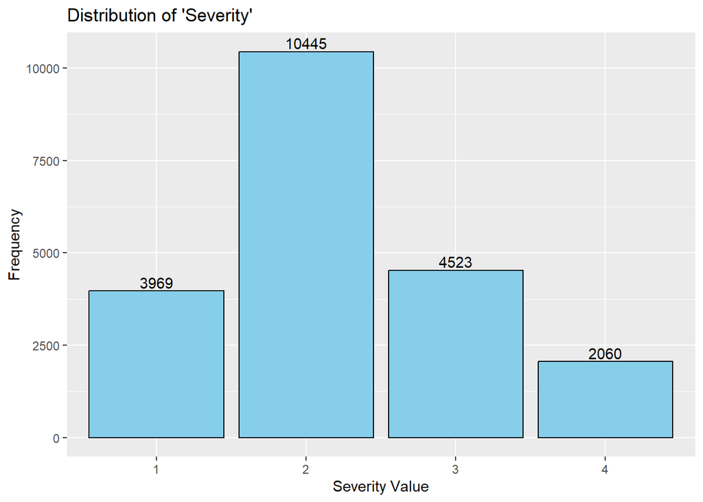

```r
LA_crime_subset%>%
  ggplot(aes(x=Severity))+
  geom_bar(fill="skyblue",color="black")+
  geom_text(aes(label=..count..),stat="count",vjust=-0.25)+
  labs(title="Distribution of 'Severity'", x="Severity Value",y="Frequency")
```

From the above bar chart, we can observe that the distribution of `severity` is right skewed, with more observations falling into the lower levels of `severity`, rather than the higher, more serious levels. This is not very surprising, as it is logical that the majority of offenses that occur in Los Angeles, even in its most crime-ridden neighborhoods, are not violent crimes, lethal crimes, felonies, or sexual crimes. We should also note that the most common level of `severity` is `2`, which indicates that property related crimes and misdemeanors happen at a much higher rate than other crimes in these neighborhoods of LA. This checks out, as urban areas with high population density often experience a surplus of various forms of theft and vandalism.

### Correlation Plot Amongst Variables

For our next step in the EDA process, it seems logical to proceed with a correlation plot amongst the variables in our dataset to observe the underlying relationships that we may not yet be aware of. This should help us identify which variables will be most relevant for our modeling process going forward. It is only relevant to include a correlation plot amongst numeric variables, or those for which there is an underlying numeric structure that is productive to examine linear relationships with:

```r
head(LA_crime_subset)
```

```
## # A tibble: 6 × 19
##   TIME.OCC AREA  AREA.NAME   Rpt.Dist.No Part.1.2 Crm.Cd Vict.Age Vict.Sex
##      <int> <fct> <fct>       <fct>       <fct>    <fct>     <dbl> <fct>
## 1     1030 12    77th Street 1265        2        753          NA X
## 2     2000 12    77th Street 1235        1        310          NA X
## 3     1800 12    77th Street 1258        2        903          29 M
## 4     1130 12    77th Street 1211        1        236          54 M
## 5     2100 12    77th Street 1251        2        812           5 M
## 6     2000 12    77th Street 1273        1        510          NA No Sex
## # ℹ 11 more variables: Vict.Descent <fct>, Premis.Cd <fct>, LOCATION <fct>,
## #   LAT <dbl>, LON <dbl>, Weapon.Used <fct>, Severity <ord>, Year.OCC <fct>,
## #   Month.OCC <fct>, Weekday.OCC <ord>, Season.OCC <fct>
```

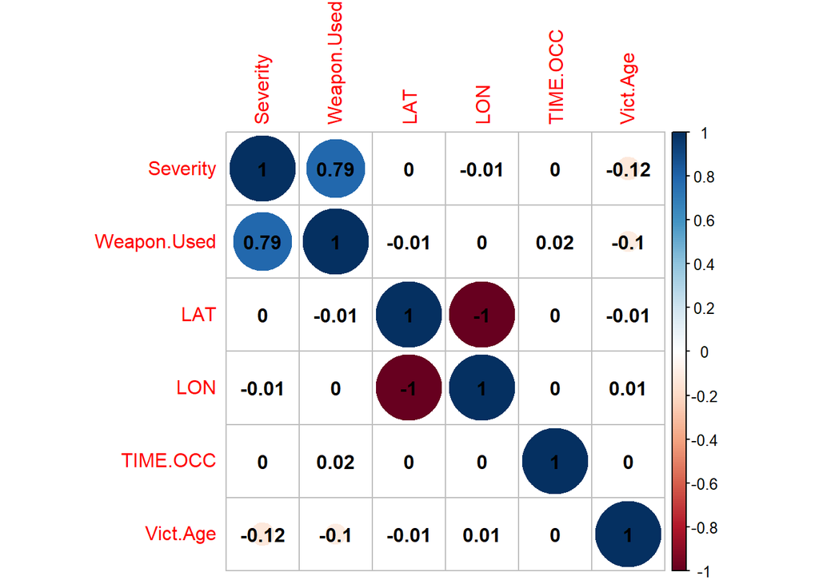

```r
num_crime_vars <- LA_crime_subset %>%
  select(Severity, Weapon.Used, LAT, LON, TIME.OCC, Vict.Age)

#coerce some of our categorical variables with underlying numerical structure to numerical values in order to run a correlation plot using their values
num_crime_vars <- num_crime_vars %>%
  mutate(Severity = as.numeric(Severity), Weapon.Used = as.numeric(Weapon.Used))

corr_mat <- cor(num_crime_vars, use = "complete.obs")
corrplot(corr_mat, method = "circle",addCoef.col = TRUE)
```

Before we proceed to our categorical variables, I would like to further examine the relationship between `Vict.Age` and `Severity`, as I thought that their negative correlation was slightly odd. Let us accomplish this using `ggplot2` with `geom_histogram()` and the structure of a stacked bar chart:

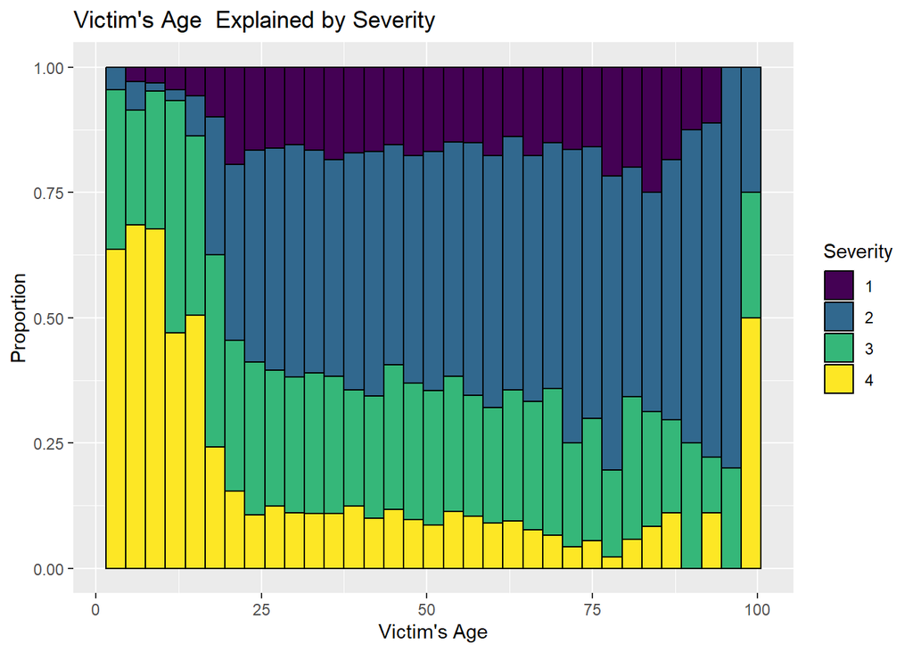

```r
ggplot(LA_crime_subset, aes(x = Vict.Age, fill = Severity)) +
  geom_histogram(binwidth = 3, position = "fill", color = "black") +
  labs(title = "Victim's Age  Explained by Severity",
       x = "Victim's Age",
       y = "Proportion",
       fill = "Severity")
```

From the above we can observe that the negative correlation displayed in the correlation plot for the relationship between `Vict.Age` and `Severity` is, in-fact correct. This is likely due to the fact that the majority of crimes against persons under 18 in our dataset were either violent(assault on a minor, child abuse,etc.) or sexual in nature (we designated sexual crimes to always be `severity` 4). As a result, this relationship makes sense and could mean that `Vict.Age` will be a good predictor for `Severity`.

While we’re here, let’s also take a second to examine the `Weapon.Used` and `Vict.Age` relation, using a stacked bar chart similar to the above.

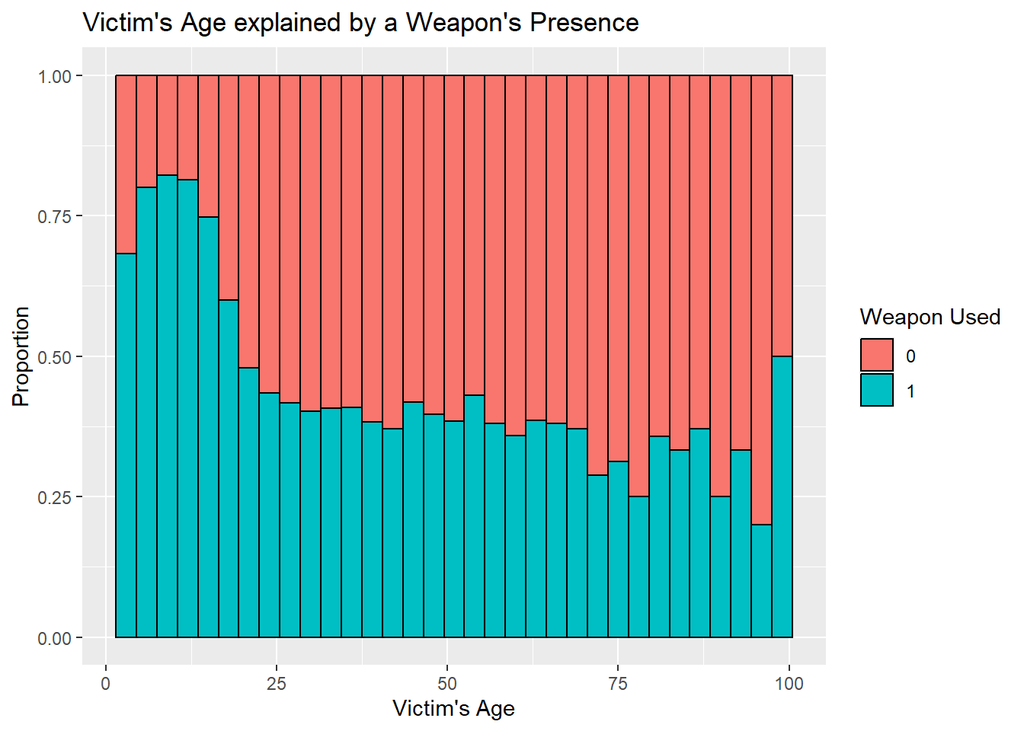

```r
ggplot(LA_crime_subset, aes(x = Vict.Age, fill = Weapon.Used)) +
  geom_histogram(binwidth = 3, position = "fill", color = "black") +
  labs(title = "Victim's Age explained by a Weapon's Presence",
       x = "Victim's Age",
       y = "Proportion",
       fill = "Weapon Used")
```

We should also take a second look at the relationship between `Severity` and `Time.OCC`. It seems logical that there could be more serious offenses committed during different parts of the day, especially during night time hours over day time hours. Lets examine this using a stacked bar chart, with bin widths set to capture distinct hour ranges of the day. These ranges are based on whether it is typically light or dark outside and the range’s appropriate time classification. We will create a copy of `LA_crime_subset` with a new variable, `Time.Period`. If `Time.Period` seems to be productive in explaining crime `Severity` it may be a good idea to add it to our dataset:

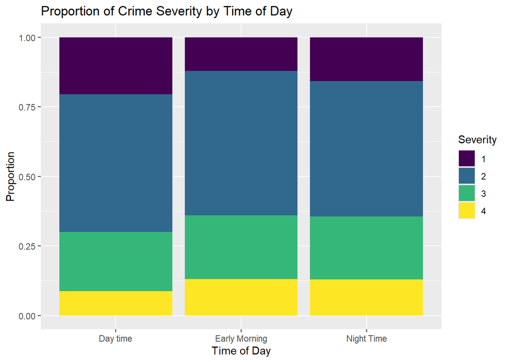

```r
LA_crime_subset1 <- LA_crime_subset %>%
  mutate(Time.Period = case_when(TIME.OCC >= 0 & TIME.OCC <= 400 ~ "Early Morning", TIME.OCC > 400 & TIME.OCC <= 2100 ~ "Day time", TIME.OCC > 2100 & TIME.OCC <= 2400 ~ "Night Time"))

ggplot(LA_crime_subset1, aes(x = Time.Period, fill = Severity)) +
  geom_bar(position = "fill") +
  labs(x = "Time of Day", y = "Proportion", fill = "Severity",
       title = "Proportion of Crime Severity by Time of Day")
```

Examining this stacked bar chart with respect to the time ranges during which crimes in our dataset were committed, we can see that the distribution of crimes throughout the day are fairly similarly distributed, with some slight differences that could be notable. There appear to be more `severity` 3 and 4 crimes committed in the early morning hours. This is also the case with night time hours. Since there was not a meaningful relationship between `TIME.OCC` and `severity` when it is considered as a numerical value. Let’s mutate in these new variables into our actual dataset to try to provide a better prediction for `severity` when we begin modeling.

```r
LA_crime_subset <- LA_crime_subset %>%
  mutate(Time.Period = case_when(TIME.OCC >= 0 & TIME.OCC <= 400 ~ "Early Morning", TIME.OCC > 400 & TIME.OCC <= 2100 ~ "Day time", TIME.OCC > 2100 & TIME.OCC <= 2400 ~ "Night Time"))

LA_crime_subset$Time.Period <- as.factor(LA_crime_subset$Time.Period)
```

### Examining Relationships Amongst Categorical Variables

The analysis of relationships amongst our numerical variables, including some categorical variables that seemed productive to coerce into numeric values, did not prove to be very productive. We will now focus on the relationships amongs categorical variables.

We are interested in determining relationships between `severity` and other categorical variables in the dataset.

#### The Use of a Weapon and Crime Severity

Let’s begin by examining a stacked bar chart of `Weapon.Used` explained by `Severity`:

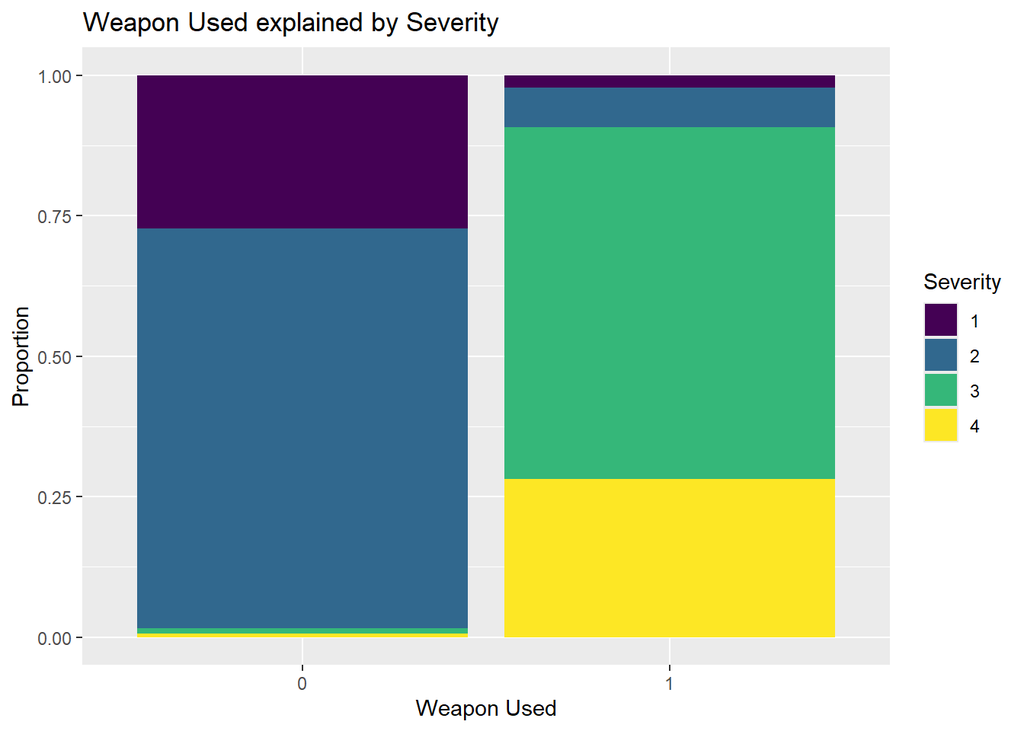

```r
ggplot(LA_crime_subset, aes(x = Weapon.Used, fill = Severity)) +
  geom_bar(position = "fill") +
  labs(title = "Weapon Used explained by Severity",
       x = "Weapon Used",
       y = "Proportion",
       fill = "Severity")
```

From the above, we can observe that the vast majority of crimes where no weapon was used received `severity`values of 1 and 2, while the vast majority of crimes where a weapon was used received `Severity` values of 3 and 4. This confirms what we already suspected, the use of a weapon is very likely to increase a crime’s `severity`.

#### Part 1 or 2 Designation and Crime Severity

Let’s now examine a stacked bar chart of `Part.1.2` explained by `Severity`

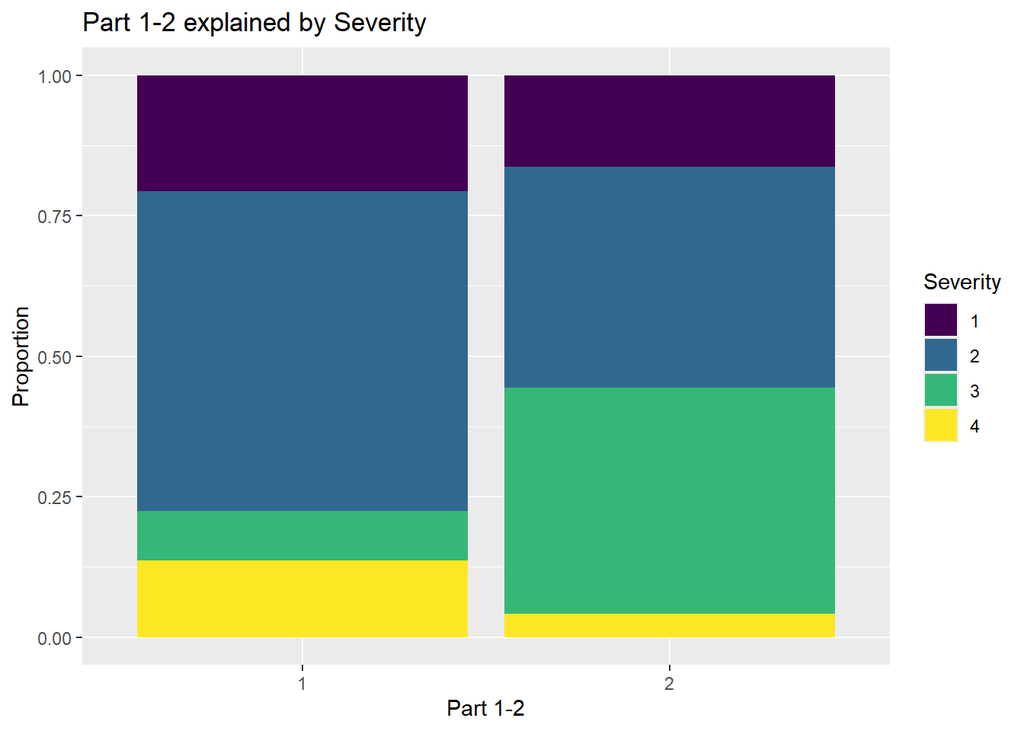

```r
ggplot(LA_crime_subset, aes(x = Part.1.2, fill = Severity)) +
  geom_bar(position = "fill") +
  labs(title = "Part 1-2 explained by Severity",
       x = "Part 1-2",
       y = "Proportion",
       fill = "Severity")
```

From the above, we can observe that part 1 crimes are largely made up of `severity` 1 and 2, with smaller but notable presence of `severity` 3 and 4. On the other hand, part 2 crimes have a more evenly distributed count of all `severity` values, except for 4.

Now let us examine the relationship between `Vict.Sex` and `Severity`:

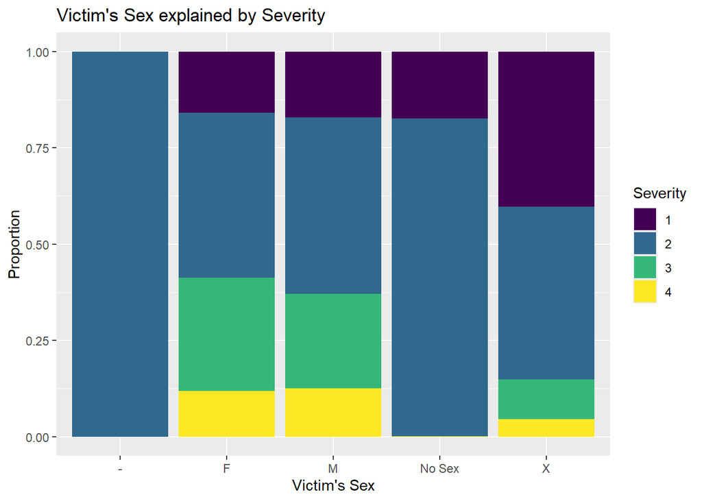

```r
ggplot(LA_crime_subset, aes(x = Vict.Sex, fill = Severity)) +
  geom_bar(position = "fill") +
  labs(title = "Victim's Sex explained by Severity",
       x = "Victim's Sex",
       y = "Proportion",
       fill = "Severity")
```

From the above, we can observe that the distribution of different grades of `Severity` of crimes committed against Males and Females in our dataset is roughly equal, with women experiencing slightly greater numbers of `Severity` 3 crimes. We can also see that crimes for which there was no clearly discernible victim are exclusively `Severity` 1 and 2, which reflects the scale with which the `Severity` values were based upon.

#### Victim’s Ethnicity and Crime Severity

Now let us examine the relationship between the victim of a crime’s ethnic background and the severity of the crime committed against them:

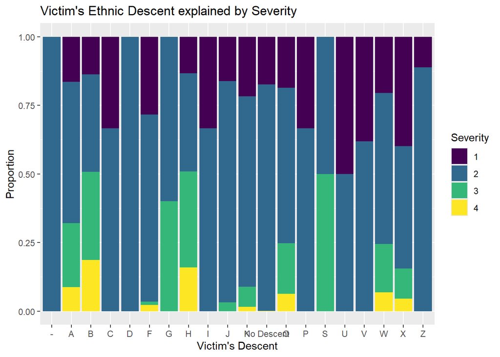

```r
ggplot(LA_crime_subset, aes(x = Vict.Descent, fill = Severity)) + geom_bar(position = "fill") +
  labs(title = "Victim's Ethnic Descent explained by Severity",x = "Victim's Descent",y = "Proportion",fill = "Severity")
```

These counts could indicate that `Vict.Desc` may assist in predicting the severity of a crime.

#### Day of the Week and Severity

Let’s examine the relationship between which day of the week a crime occurs on and its corresponding `severity`.

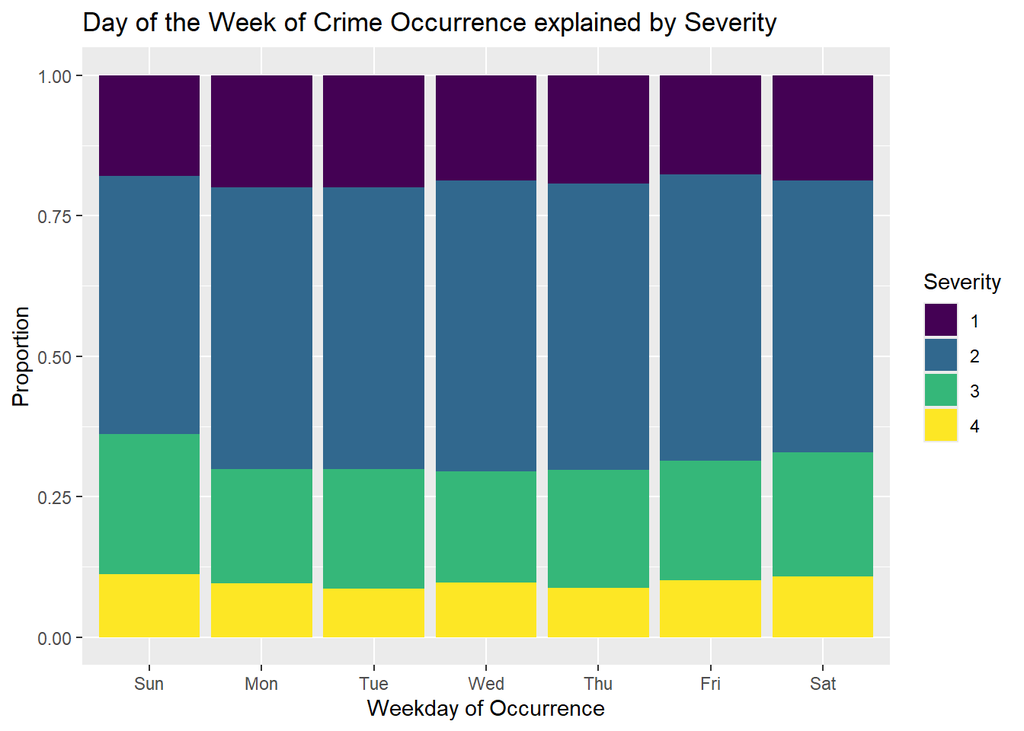

```r
ggplot(LA_crime_subset, aes(x = Weekday.OCC, fill = Severity)) +
  geom_bar(position = "fill") +
  labs(title = "Day of the Week of Crime Occurrence explained by Severity",
       x = "Weekday of Occurrence",
       y = "Proportion",
       fill = "Severity")
```

The distribution of `severity` is nearly identical for all days of the week. There is a slight increase in `severity` 3 and 4 on weekends, which suggest that a crime occurring on a weekend may result in higher probability of it being a worse offense. This suggests that our feature engineering to create day of the week was not particularly useful, as it doesn’t provide us with any productive information. Let’s correct this by encoding the useful information that we found from this plot into a new variable `WEEKEND` that is either true or false based on whether the crime occurred on a weekend:

```r
# I use the case_when() function even though this is binary mutation because ifelse() kept affecting other parts of my data when used with mutate() earlier
LA_crime_subset <- LA_crime_subset %>%
  mutate(WEEKEND = case_when(Weekday.OCC %in% c("Mon","Tue","Wed", "Thu", "Fri") ~ 0, Weekday.OCC %in% c("Sat","Sun")~ 1))

LA_crime_subset$WEEKEND <- as.factor(LA_crime_subset$WEEKEND)
```

#### Season during which a crime occurred and its Severity

Lets examine the relationship between different seasons of the year during which crimes may occur and their corresponding `severity` values:

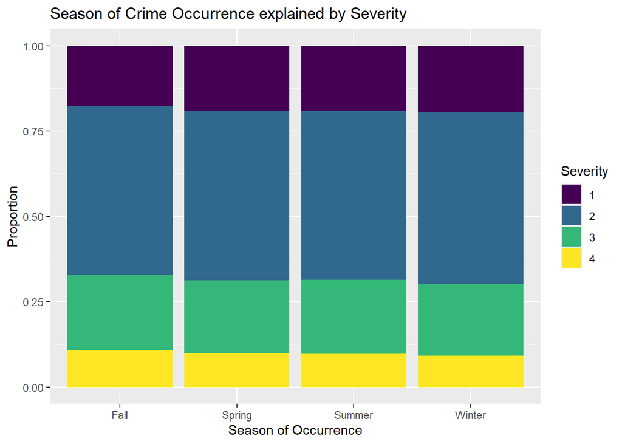

```r
ggplot(LA_crime_subset, aes(x = Season.OCC, fill = Severity)) +
  geom_bar(position = "fill") +
  labs(title = "Season of Crime Occurrence explained by Severity",
       x = "Season of Occurrence",
       y = "Proportion",
       fill = "Severity")
```

Once again, the distribution of `severity` is pretty much identical for all four seasons of the year. This suggests that the Season.OCC variable will not be very useful.

#### Month during which a crime occurred and its severity

Let’s briefly peek at the relationship between a crime’s month of occurrence and its corresponding severity distribution:

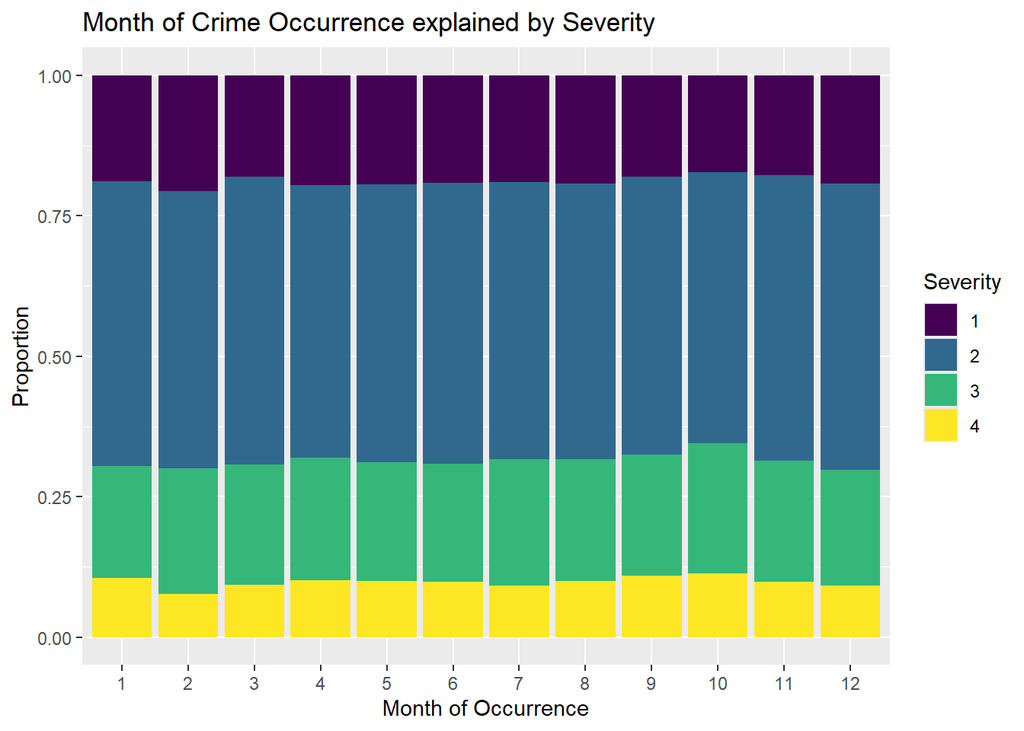

```r
ggplot(LA_crime_subset, aes(x = Month.OCC, fill = Severity)) +
  geom_bar(position = "fill") +
  labs(title = "Month of Crime Occurrence explained by Severity",
       x = "Month of Occurrence",
       y = "Proportion",
       fill = "Severity")
```

There is no substantial variation in the distribution of crime severity by month during which the crime occurred. This variable will not be likely to provide meaningful input to our model and we will most likely drop it from the modeling process later on.

#### Year where a crime occurred and its severity:

Since we have already looked at all but one the variables I attempted to feature engineer from the original `DATE.OCC` variable, we should look at the final variable, `Year.OCC`, as well and its relation to crime `severity` vlaues

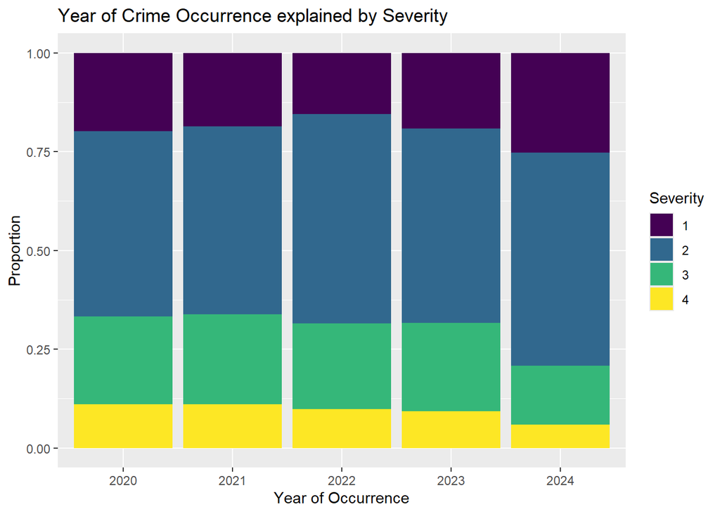

```r
ggplot(LA_crime_subset, aes(x = Year.OCC, fill = Severity)) +
  geom_bar(position = "fill") +
  labs(title = "Year of Crime Occurrence explained by Severity",
       x = "Year of Occurrence",
       y = "Proportion",
       fill = "Severity")
```

There do appear to be slightly different rates of occurrence for each `severity` value for each of the years in our dataset. There is a particularly large different between the number of different levels of crime committed during 2020 and 2024.

#### Examining relationship with “code” factor variables

Before we wrap up our EDA, we should take a brief look at the relationship between `Severity` and our remaining variables that store codes. The first of two variables left which store a code is the `Premis.Cd` variable, which describes the type of structure in which the crime took place. Observe the following:

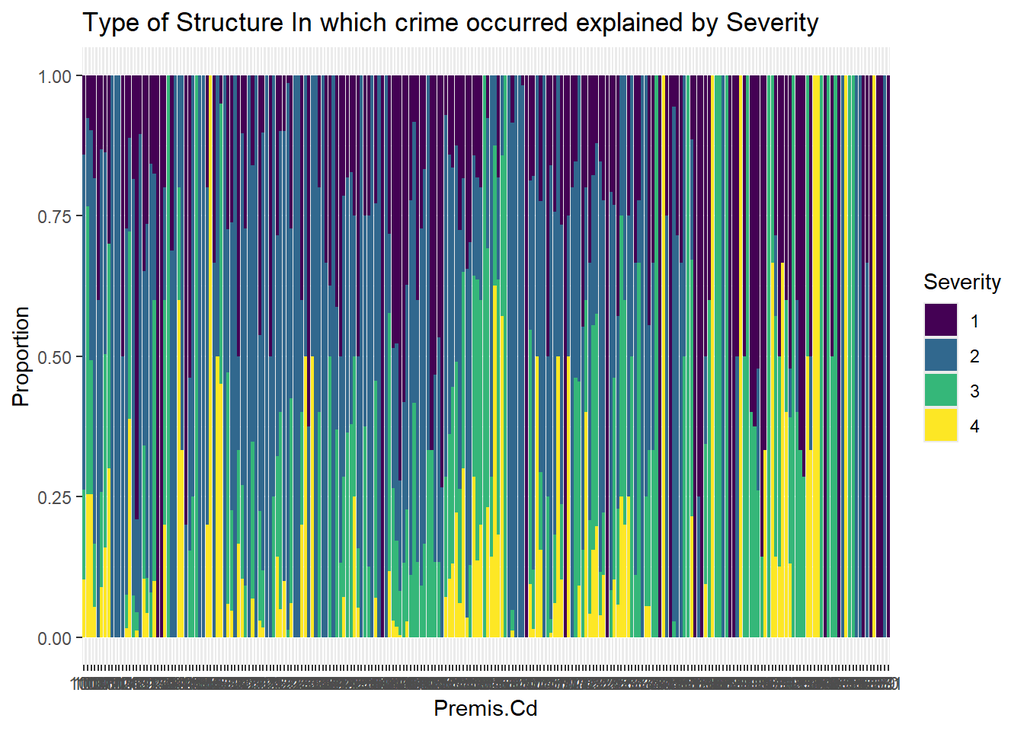

```r
ggplot(LA_crime_subset, aes(x = Premis.Cd, fill = Severity)) +
  geom_bar(position = "fill") +
  labs(title = "Type of Structure In which crime occurred explained by Severity",
       x = "Premis.Cd",
       y = "Proportion",
       fill = "Severity")
```

From the above, we can see that there are a very large amount of unique `Premis.Cd` values, which makes for a pretty jumbled graph. Even though this graph has many, many bars, we should notice that certain codes have much higher rates of high `severity` crimes that occur in these types of locations. We should note this relationship as we go forward, as it could prove useful for our models.

Let’s now check out the relationship between crime `severity` and the area in which the crime was committed. We have two variables which describe this, `AREA` and `AREA.NAME`. These two variables are technically the storing the same value, but lets use the more descriptive one, `AREA.NAME`, so that we know which neighborhoods we are actually referring to, rather than just their numerical codes.

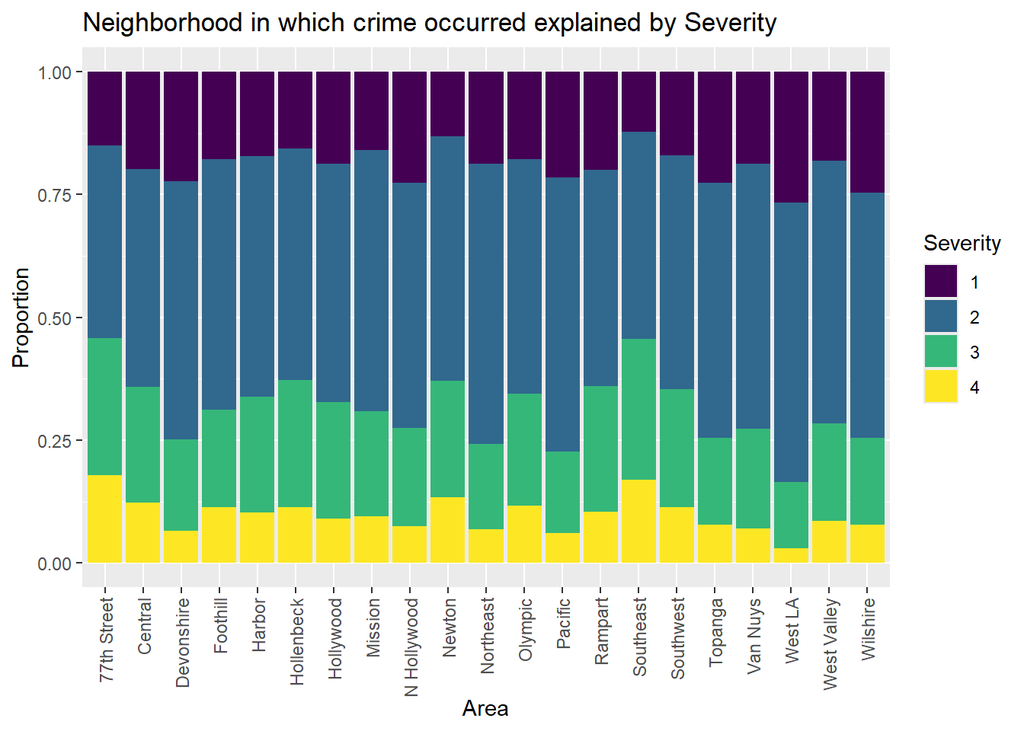

```r
ggplot(LA_crime_subset, aes(x = AREA.NAME, fill = Severity)) +
  geom_bar(position = "fill") +
  labs(title = "Neighborhood in which crime occurred explained by Severity",
       x = "Area",
       y = "Proportion",
       fill = "Severity")+
  theme(axis.text.x = element_text(angle = 90, hjust = 1, vjust = 0.5))
```

From the above, we can see that certain neighborhoods have significantly higher rates of high `severity` crimes, while others have much lower rates of these crimes. This could be due to a number of factors, including the economic/class state of certain neighborhoods, gang or drug related activity in others, and higher police patrol rates in more affluent areas. Regardless, `AREA` could be a meaningful predictor of `severity`.

Now that we have examined many of the variables in our dataset and their relationships visually, lets proceed to the beginning of the actual modeling process.

## Model Set-up

Now that we have a basic idea of which variables will likely prove useful to our model, its time to proceed with the actual modeling process itself. I know, its such a relief! Looking at data for so long can become tedious, especially with data such as this crimes dataset that does not always have an entirely clear structure or embedded relationships throughout.

### Splitting the dataset

Before we can proceed to recipe creation and model specifications, we must first split our larger dataset into training and testing sets. The purpose of this is to preserve the integrity of our models through having an untouched set for which we can test models that are trained on the training set on. Having a training and testing set helps us avoid overfitting by evaluating a model’s performance on unseen data, rather than the training data that it is already familiar with. Additionally, we will not be touching the testing set after its creation, at least until it is time to truly evaluate model performance. We will also only evaluate the model’s performance on the testing set one singular time. Preserving the untouched nature of the testing set helps prevent data leakage, which occurs when we attempt to wrongly introduce the testing set to our training process with the misguided goal of boosting model performance.

When we split the data into training and testing, we must also ensure that we take extra steps to guarantee that our process is reproducible by specifying a seed before doing so. Let’s split the data:

```r
# seed(123) is my personal favorite, it just has a certain ring!
set.seed(123)

#split the data, we use proportion=70/30 training/testing
crimedata_split <- LA_crime_subset %>%
  initial_split(prop=0.7, strata=Severity)

#store
crimedata_train <- training(crimedata_split)
crimedata_test <- testing(crimedata_split)
```

Now, we have a reproducible process that splits our `LA_crime_subset` data into two datasets, where one is for training and contains 70% of the data while the other contains 30% of the data and will later be used for testing. We have also specified for our split to occur using stratified-sampling with regards to the outcome variable `Severity`. The use of stratified sampling will ensure that we have equal proportions of the levels of the outcome variable in both our training and testing sets

### Specifying the Model Recipe

Now that we have a training set and a testing set, we need a recipe that can be fed into any of the four machine learning models that we will try to apply to the training data. This recipe is generic to any model, which is very useful as it means we do not need to create many different recipes, which could be tedious.

Let’s create our recipe while taking into consideration everything we have observed throughout the pre-processing, tidying, and EDA steps so far.

- Note : W will not be including the `Crm.Cd` variable as a predictor, since doing so would make the models deterministic as `Crm.Cd` was directly used to assign `Severity` values to all observations in the dataset.
- Additional note: We will not be including the following variables:
1. `Crm.Cd` - For the above mentioned reason.
2. `TIME.OCC` - We have already stored what seemed to be the relevant take away from the `TIME.OCC` variable in the `Time.Period` variable.
3. `AREA` - `AREA` and `AREA.NAME` encode the same geographical information, so I will keep `AREA.NAME` as it is easier to interpret.
4. `LOCATION` - We already have multiple variables that refer to geographical information, additionally this is a character string coerced into a factor and there are hundreds of unique locations.
5. `Weekday.OCC` - We have stored the relevant weekday information in the `WEEKEND` variable
6. `Month.OCC` - did not provide meaningful information regarding `severity`
7. `Season.OCC` - did not provide meaningful information regarding `severity`
8. `LAT` - correlation plot showed 0 relation between `LAT` and outcome.
9. `LON` - correlation plot showed 0 relation between `LON` and outcome.
- One Last Note: At this step in the process, we technically still have missing data for the `Vict.Age` variable. This was discussed during the pre-processing and tidying sections, but seems relevant to mention again before we proceed with recipe creation. Missing values for `Vict.Age` were originally encoded as 0, which affects the numerical distribution of the age variable. These missing values were for crimes that did not necessarily have a clear victim, not one where the victim was literally an infant in the womb. Therefore, it was appropriate to change these values to `NA` rather than `0`. Additionally, now that we have arrived to our recipe creation step, I will not be imputing `Vict.Age` values, as this would impose age values on instances where there should not be any.

```r
#Recipe definition, we dummy variable encode all categorical vars:
crime_recipe <- recipe(Severity~ AREA.NAME + Rpt.Dist.No + Part.1.2 + Vict.Age + Vict.Sex + Vict.Descent +Premis.Cd + Weapon.Used+Year.OCC + Time.Period + WEEKEND, data = LA_crime_subset) %>%
  step_dummy(AREA.NAME) %>%
  step_dummy(Rpt.Dist.No) %>%
  step_dummy(Part.1.2) %>%
  step_dummy(Vict.Sex) %>%
  step_dummy(Vict.Descent) %>%
  step_dummy(Premis.Cd) %>%
  step_dummy(Weapon.Used) %>%
  step_dummy(Year.OCC) %>%
  step_dummy(Time.Period) %>%
  step_naomit(all_predictors(),skip=FALSE) %>%
  step_center(all_numeric_predictors()) %>%
  step_scale(all_numeric_predictors())
```

Before we proceed to the next steps in our process, we should examine what our training dataset will look like once this recipe is applied. This is extremely relevant, as we had a large amount of categorical predictors.

We are most interested in how many predictors we will have after the dummy encoding process takes place, as this will determine the appropriate choices for our hyperparameters. Additionally, if we have too many predictors in our training dataset after the recipe is applied, our models could take many hours, if not days or longer to tune. Let’s do this using the `prep` and `bake` functions:

```r
#using lab code, we can do this all in one fell swoop
prelim <- prep(crime_recipe) %>%
  bake(new_data = crimedata_train)
print(ncol(prelim)-1)
```

```
## [1] 1394
```

```r
unique_premis.cd <- LA_crime_subset %>%
  distinct(Premis.Cd) %>%
  nrow()

unique_rpt.dist.no <- LA_crime_subset %>%
  distinct(Rpt.Dist.No) %>%
  nrow()

unique_premis.cd
```

```
## [1] 230
```

```r
unique_rpt.dist.no
```

```
## [1] 1113
```

```r
#same recipe as before, just without Rpt.Dist.No, and premis.cd
crime_recipe <- recipe(Severity~ AREA.NAME + Part.1.2 + Vict.Age + Vict.Sex + Vict.Descent + Weapon.Used+Year.OCC + Time.Period + WEEKEND, data = LA_crime_subset) %>%
  step_dummy(AREA.NAME) %>%
  step_dummy(Part.1.2) %>%
  step_dummy(Vict.Sex) %>%
  step_dummy(Vict.Descent) %>%
  step_dummy(Weapon.Used) %>%
  step_dummy(Year.OCC) %>%
  step_dummy(Time.Period) %>%
  step_dummy(WEEKEND) %>%
  step_naomit(all_predictors(),skip=TRUE) %>%
  step_center(all_numeric_predictors()) %>%
  step_scale(all_numeric_predictors())
```

This recipe should now be much more manageable for tuning hyperparameters later on.

Now that we have specified a recipe, there a few more steps we must complete before we are ready to apply this recipe to our prospective models.

### Applying K-Fold Cross Validation

We use k-fold cross-validation, rather than simply comparing our model results on the entire training set, in order to avoid introducing bias/poor performance due to over-fitting into our model. When we compare model results on the entire training set, we may produce deceivingly accurate performance metrics because we are evaluating the performance of our model based on data it is already familiar with, rather than unseen data. When k-fold cross-validation is applied, we simulate unseen data by using k-1 folds for training and the k-th fold for evaluating performance.

In the case of this dataset, we have a decently large number of observations, as well as a fairly large number of predictors. As a result, we may want to steer clear of picking a value for ‘k’ that is too large. Pairing a large number of folds with a lengthy, highly dimensional dataset can be incredibly computationally intense (intensity that my little HP laptop might struggle to accommodate on a reasonable time frame). As a result, we will use a fairly standard number of folds: k=5.

Let’s apply this k=5 cross validation:

```r
# set our seed again, just in case.
set.seed(123)

#Create 5-fold CV object
crime_folds <- vfold_cv(LA_crime_subset, v=5)
```

Now that we have a 5-fold cross validation object created from our `LA_crime_dataset`, we can proceed to the actual modeling process.

This is where things get interesting!

## Building Our Models

Now that we have all of the necessary components, its time to tackle the actual model-building process. Of the models we have examined throughout this course, the ones which seem most appropriate to apply to our data, since it is a multi-class classifcation problem, are:

1. Elastic Net Logistic Regression
2. Random Forest
3. Support Vector Machines (SVMs)
4. Gradient Boosted Trees

Let’s proceed with building these models for the classification problem at hand in sequential order. A general framework for each model shall be:

1. Define a model specification with a suitable model engine and select ‘classification’ as the mode.
2. Add the specification and the crime recipe to a workflow.
3. Create a tuning grid for any hyperparameter(s) required by each model.
4. Tune each model using our `crime_folds` object.

### Creating Model Specifications:

Our first step in the process of building and applying models to our data is creating a specification object for each model that sets its engine and mode appropriately. We must do this for all four models individually

```r
#EN logistic regression specifications, we will be tuning penalty().
# ran into an error when tuning, needed to come back and specific multinomial logistic regression, as the default is binomial
#Encountered another error after running family="multinomial", console message suggested using multinom_reg() instead
glm_spec <- multinom_reg(penalty=tune(),mixture=tune()) %>%
  set_engine("glmnet") %>%
  set_mode("classification") #%>%
  #set_args(family="multinomial")

#random forest specification, we will be tuning mtry(),trees(), and min_n().
randforest_spec <- rand_forest(mtry=tune(),trees=tune(),min_n=tune()) %>%
  set_engine("ranger",importance= "impurity") %>%
  set_mode("classification")

#support vector machine (SVM) specification, we will be tuning cost() and rbf_sigma().
svm_spec <- svm_rbf(cost=tune(),rbf_sigma=tune()) %>%
  set_engine("kernlab") %>%
  set_mode("classification")

#gradient boosted tree, we will be tuning trees(), learn_rate(), and min_n().
gbt_spec <- boost_tree(trees=tune(),learn_rate=tune(),min_n=tune()) %>%
  set_engine("xgboost") %>%
  set_mode("classification")
```

We now have stored objects for each model that specify the model, which hyperparameters we will be tuning, the appropriate model engine, and our desired goal of classification.

Now, on to the next step!